# Scoring model for Default of Credit Card Clients

### BILL_AMT6

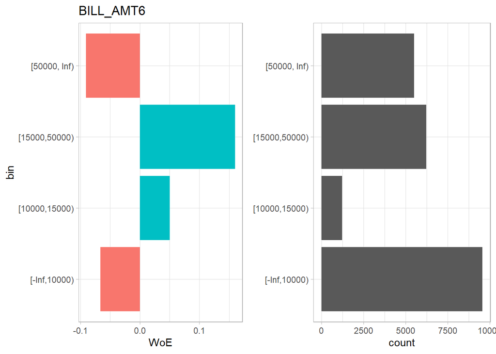

### PAY_AMT1

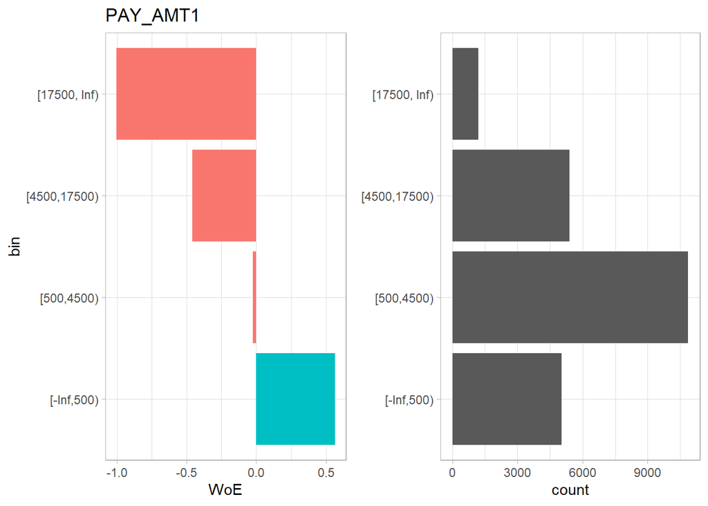

### PAY_AMT2

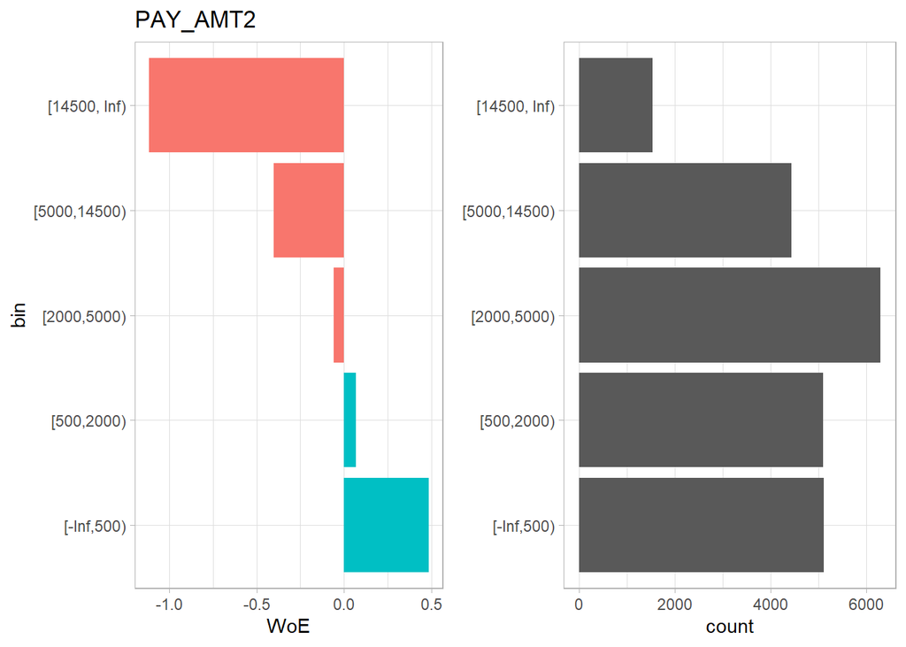

### PAY_AMT3

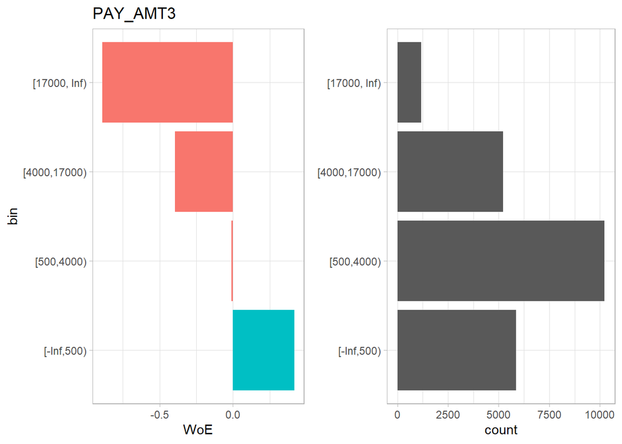

### PAY_AMT4

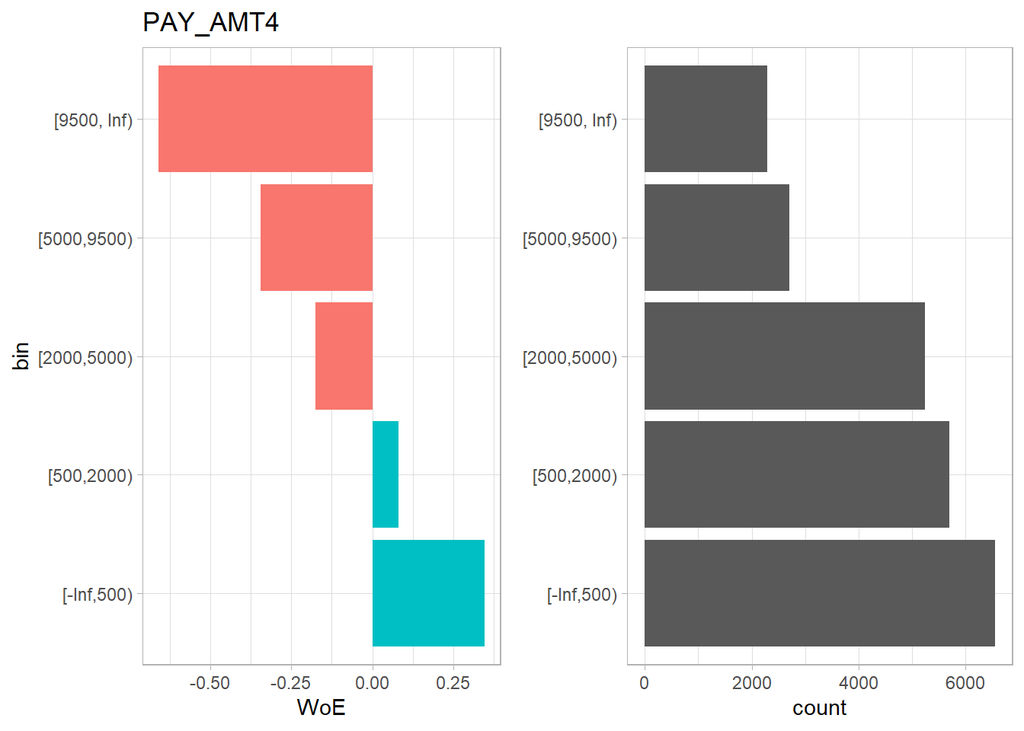

### PAY_AMT5

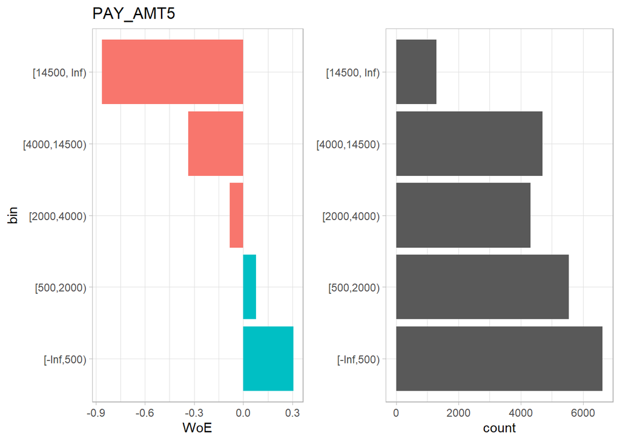

### PAY_AMT6

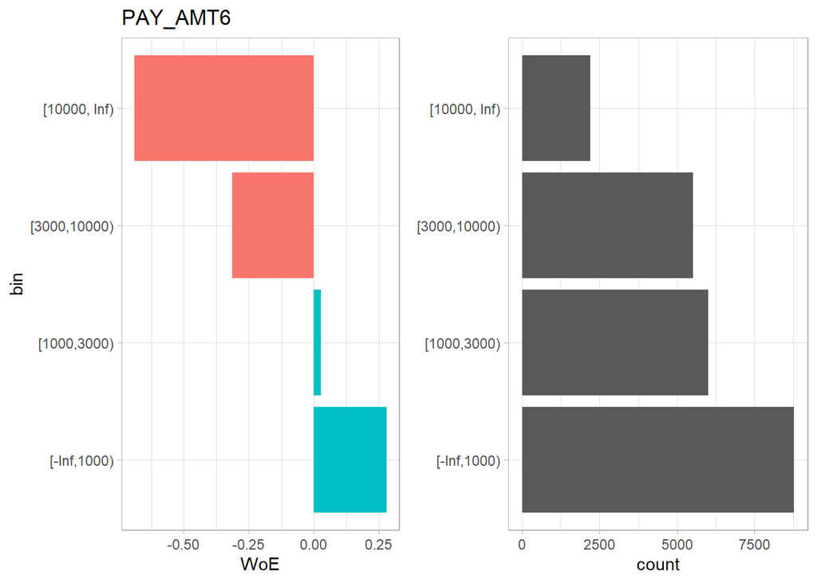

### SEX

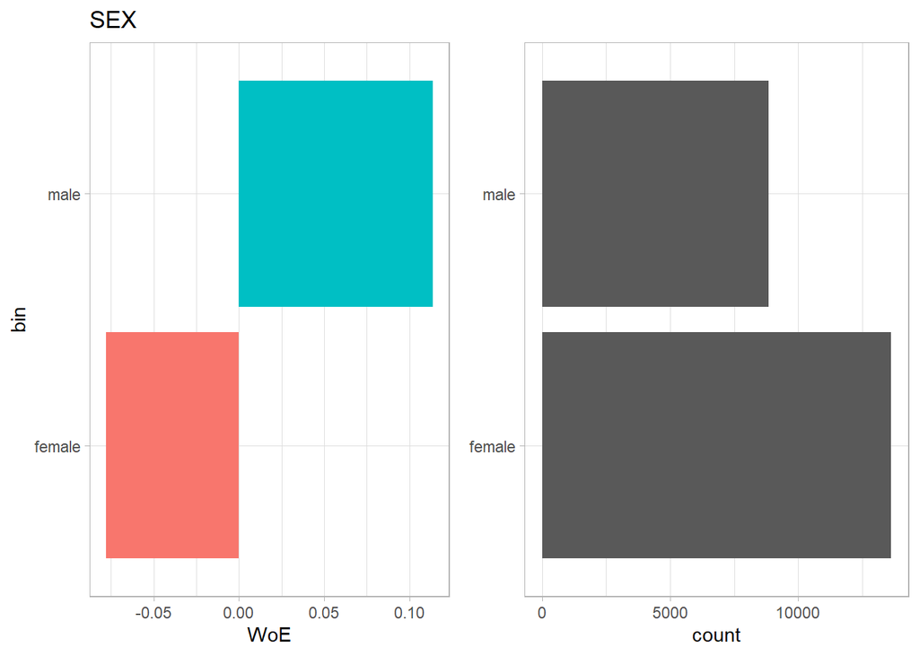

### EDUCATION

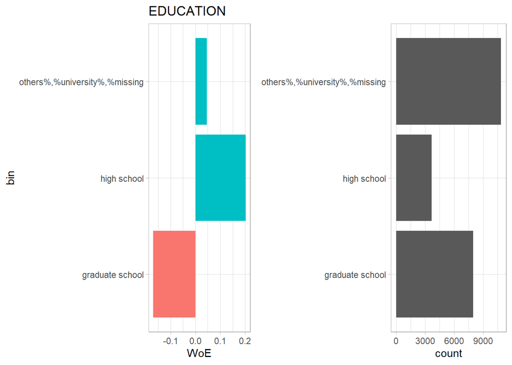

### MARRIAGE

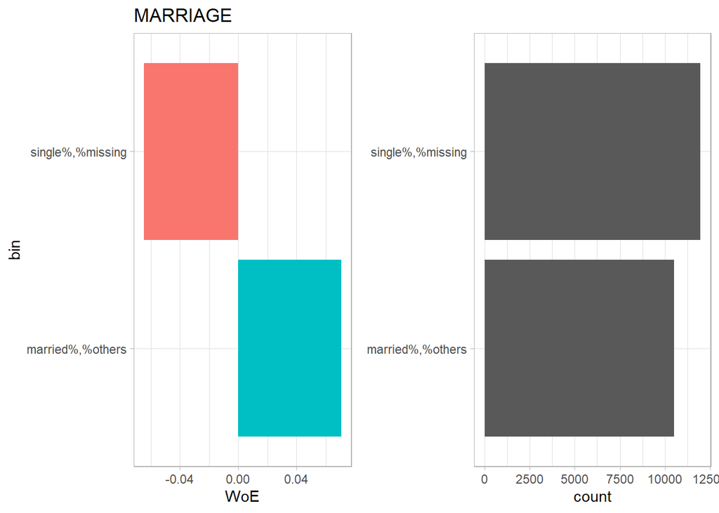

### PAY_3

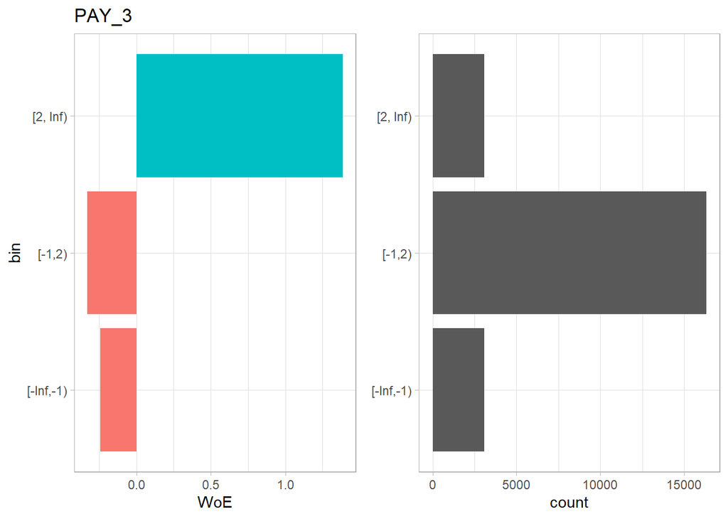

### PAY_5

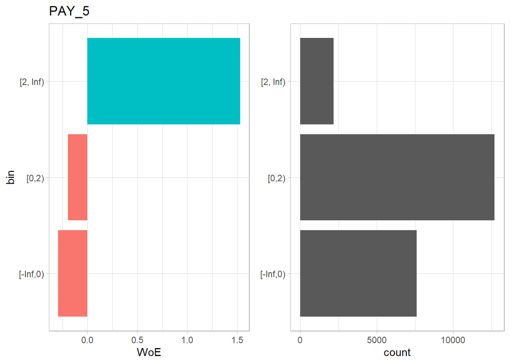

### PAY_6

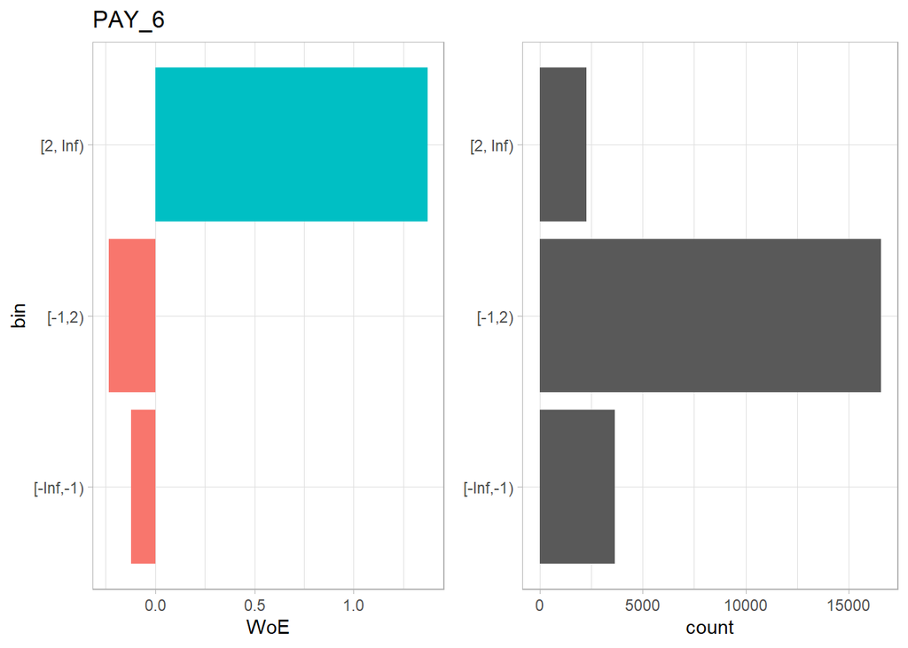

# Model

## Correlations check

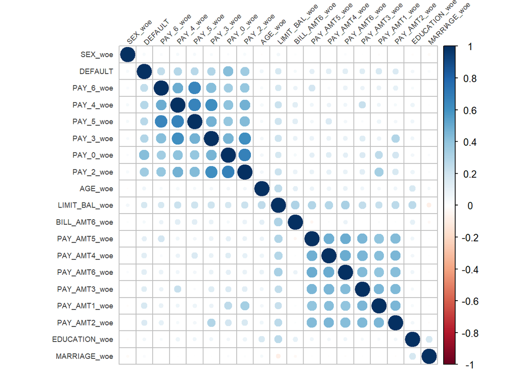

```r
cor_M2 <- cor(df_learn_woe )
cor_plot2 <- corrplot(cor_M2,
                     method = 'circle',
                     type = 'full',
                     order = 'hclust',
                     tl.col = 'grey20',
                     tl.cex = 0.6,
                     tl.srt = 45)
```

We can see, that there are still quite correlated variables, but for now this is sufficient. Later we will examine Variance Inflation Factor after building the model.

## Balancing dataset

Due to unequal proportion of Default and Non-Default we need to balance dataset by adding weights to every observation.

```r
weights_vec <- ifelse(df_learn_woe$DEFAULT == 1, 4, 1)
```

## Building Logistic Regression Model

Due to small number of variables at this point, there is no need to use step function to perform feature selection. We will use error and trial method to select most informative variables. The most importat part is to be careful with estimated coefficient: because variables are transformed by WoE, coefficients should be all positive. Negative coefficient would suggest reverse relationship between predictor and response variable from what was obtained during WoE transformation.

```r
vars_names <- c(
"LIMIT_BAL_woe"
#,"AGE_woe"
,"PAY_0_woe"
#,"PAY_2_woe"
,"PAY_4_woe"
#,"BILL_AMT6_woe"
,"PAY_AMT1_woe"
,"PAY_AMT2_woe"
#,"PAY_AMT3_woe"
#,"PAY_AMT4_woe"
,"PAY_AMT5_woe"
,"PAY_AMT6_woe"
,"SEX_woe"
#,"EDUCATION_woe"
,"MARRIAGE_woe"
)

formula <- as.formula(paste("DEFAULT ~ ", paste(vars_names, collapse= "+")))

model <- glm(df_learn_woe,
             formula = formula,
             family = 'binomial',
             weights =  weights_vec)

summary(model)
```

```
##
## Call:
## glm(formula = formula, family = "binomial", data = df_learn_woe,
##     weights = weights_vec)
##
## Deviance Residuals:
##     Min       1Q   Median       3Q      Max
## -2.6674  -1.0720  -0.9001  -0.6591   4.0692
##
## Coefficients:
##               Estimate Std. Error z value Pr(>|z|)
## (Intercept)    0.12051    0.01203  10.017  < 2e-16 ***
## LIMIT_BAL_woe  0.46729    0.02974  15.711  < 2e-16 ***
## PAY_0_woe      0.80283    0.01465  54.790  < 2e-16 ***
## PAY_4_woe      0.50292    0.02264  22.210  < 2e-16 ***
## PAY_AMT1_woe   0.28153    0.03370   8.355  < 2e-16 ***
## PAY_AMT2_woe   0.38964    0.03585  10.867  < 2e-16 ***
## PAY_AMT5_woe   0.20988    0.04801   4.372 1.23e-05 ***
## PAY_AMT6_woe   0.18937    0.04679   4.047 5.19e-05 ***
## SEX_woe        0.76553    0.12554   6.098 1.08e-09 ***
## MARRIAGE_woe   1.23029    0.17455   7.048 1.81e-12 ***
## ---
## Signif. codes:  0 '***' 0.001 '**' 0.01 '*' 0.05 '.' 0.1 ' ' 1
##
## (Dispersion parameter for binomial family taken to be 1)
##
##     Null deviance: 51603  on 22499  degrees of freedom
## Residual deviance: 42286  on 22490  degrees of freedom
## AIC: 42306
##
## Number of Fisher Scoring iterations: 5
```

## VIF

Finally, last check for some collinearity of variables by calculating Variance Inflation Factor.

```r
vif(model)
```

```
##         variable     gvif
## 1: LIMIT_BAL_woe 1.146844
## 2:     PAY_0_woe 1.118473
## 3:     PAY_4_woe 1.096989
## 4:  PAY_AMT1_woe 1.354268
## 5:  PAY_AMT2_woe 1.389741
## 6:  PAY_AMT5_woe 1.442329
## 7:  PAY_AMT6_woe 1.460505
## 8:       SEX_woe 1.006377
## 9:  MARRIAGE_woe 1.011163
```

Vifs below 1.5 suggests very small amount of collinearity (anything above 2 should be suspicious).

## Prediction

Next, we will transform test set and gather results in one data frame with original variables, WoE transformed variables and prediction.

```r
# LEARN_SET
df_learn_final <- cbind(df_learn  %>% select(-DEFAULT), df_learn_woe)
df_learn_final$y_pred <- model$fitted.values
df_learn_final$set <- 'learn'

# TEST_SET
df_test_sel <- df_test %>% select(all_of(c(names(df_woebin), 'DEFAULT')))
df_test_woe <- scorecard::woebin_ply(df_test_sel, bins = df_woebin )
```

```
## [INFO] converting into woe values ...
```

```r
df_test_final <- cbind(df_test %>% select(-DEFAULT), df_test_woe)
df_test_final$y_pred <- predict(model, df_test_woe, type = 'response' )
df_test_final$set <- 'test'

# FINAL_SET
df_final <- rbind(df_learn_final, df_test_final)
df_final$y_pred_bin <- cut(
  df_final$y_pred,
  breaks = quantile(df_final$y_pred, probs = seq(0, 1, by = 0.1)),
  include.lowest = TRUE,
  right = TRUE)


head(df_final) %>% kable() %>%
  kable_styling(bootstrap_options = "hover") %>%
  scroll_box(width = "800px", height = "400px")
```

| LIMIT_BAL | SEX | EDUCATION | MARRIAGE | AGE | PAY_0 | PAY_2 | PAY_3 | PAY_4 | PAY_5 | PAY_6 | BILL_AMT1 | BILL_AMT2 | BILL_AMT3 | BILL_AMT4 | BILL_AMT5 | BILL_AMT6 | PAY_AMT1 | PAY_AMT2 | PAY_AMT3 | PAY_AMT4 | PAY_AMT5 | PAY_AMT6 | DEFAULT | LIMIT_BAL_woe | AGE_woe | PAY_0_woe | PAY_2_woe | PAY_4_woe | BILL_AMT6_woe | … |
| --- | --- | --- | --- | --- | --- | --- | --- | --- | --- | --- | --- | --- | --- | --- | --- | --- | --- | --- | --- | --- | --- | --- | --- | --- | --- | --- | --- | --- | --- | --- |
| 50000 | male | university | married | 33 | 0 | 0 | 0 | 0 | 0 | 0 | 47048 | 24058 | 25042 | 21947 | 19198 | 19610 | 1445 | 1429 | 1294 | 1000 | 705 | 699 | 0 | 0.1967003 | -0.1731683 | -0.6659520 | -0.4223825 | -0.2364008 | 0.1600234 | … |
| 150000 | female | graduate school | single | 26 | -1 | -1 | -1 | -1 | -1 | -1 | 15079 | 5018 | 6701 | 54574 | 983 | 25580 | 5018 | 6701 | 54579 | 983 | 25580 | 26738 | 0 | -0.3425082 | -0.0554647 | -0.4682938 | -0.4223825 | -0.3134352 | 0.1600234 | … |
| 50000 | male | graduate school | single | 35 | 0 | 0 | 0 | 0 | 0 | 0 | 48264 | 19142 | 18188 | 18397 | 18161 | 18383 | 1565 | 7240 | 795 | 1000 | 673 | 647 | 1 | 0.1967003 | -0.1731683 | -0.6659520 | -0.4223825 | -0.2364008 | 0.1600234 | … |
| 140000 | male | graduate school | single | 50 | -1 | 2 | -1 | -1 | -1 | -1 | 780 | 780 | 390 | 0 | 780 | 390 | 0 | 390 | 0 | 780 | 390 | 0 | 1 | -0.3425082 | 0.1763656 | -0.4682938 | 1.5447226 | -0.3134352 | -0.0659810 | … |
| 330000 | male | university | married | 34 | -1 | -1 | -2 | -2 | -2 | -2 | 901 | 0 | 0 | 0 | 0 | 0 | 0 | 0 | 0 | 0 | 0 | 0 | 0 | -0.3425082 | -0.1731683 | -0.4682938 | -0.4223825 | -0.3134352 | -0.0659810 | … |
| 180000 | female | university | single | 31 | 1 | -2 | -2 | -2 | -2 | -2 | 0 | 0 | 0 | 0 | 0 | 0 | 0 | 0 | 0 | 0 | 0 | 0 | 1 | -0.3425082 | -0.1731683 | 0.6449966 | -0.2379210 | -0.3134352 | -0.0659810 | … |

## Diagnostics

For diagnostics we will use utility functions which I’ve created to show distributions of Goods/Bads, ROC curve and Gain Chart.

```r
df_final %>%
  group_by(set) %>%
  summarise(
    Gini = MLmetrics::Gini(y_pred, DEFAULT),
    AUC = MLmetrics::AUC(y_pred, DEFAULT)
  ) %>%
  kable() %>% kable_styling(full_width = F)
```

| set | Gini | AUC |
| --- | --- | --- |
| learn | 0.5437231 | 0.7718670 |
| test | 0.5092852 | 0.7546334 |

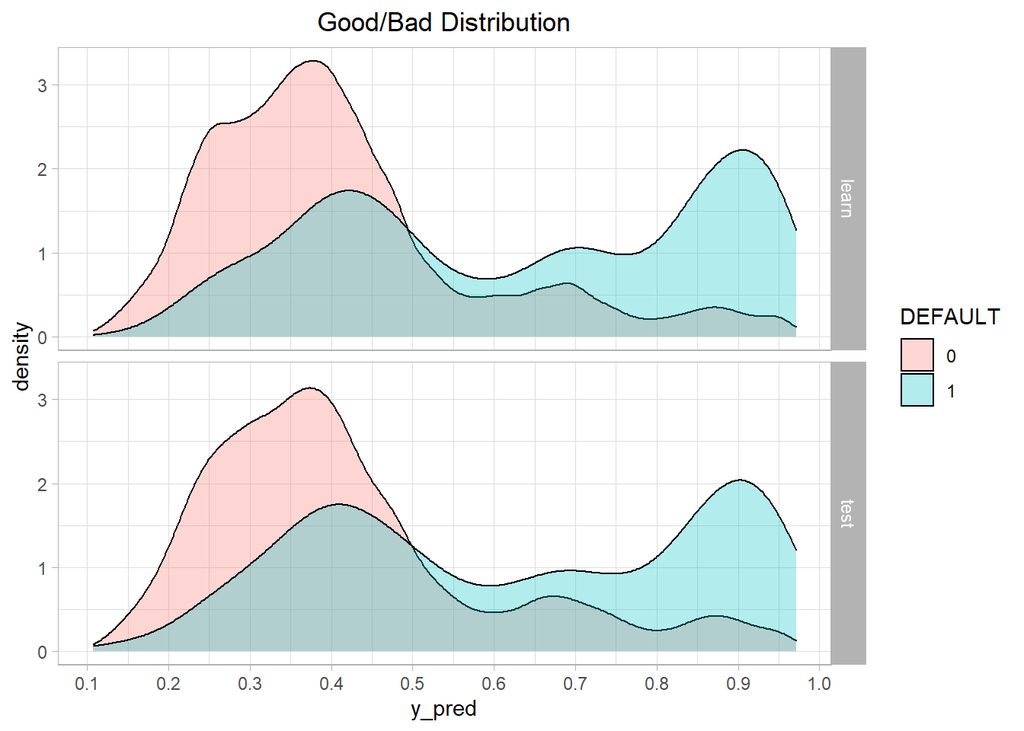

```r
plotGoodBadDist(df_final, y_pred = 'y_pred', y_real = 'DEFAULT', set_var = 'set' )
```

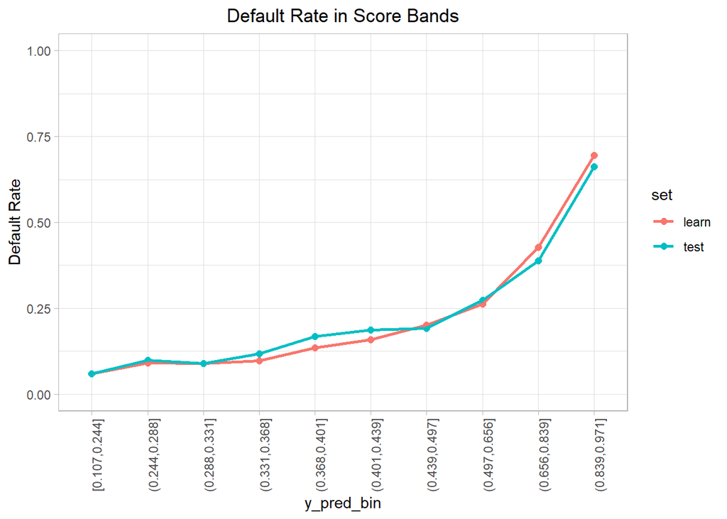

```r
plotSuccessRateInBins(df_final,'y_pred_bin','DEFAULT', 'set', 'Default Rate' )
```

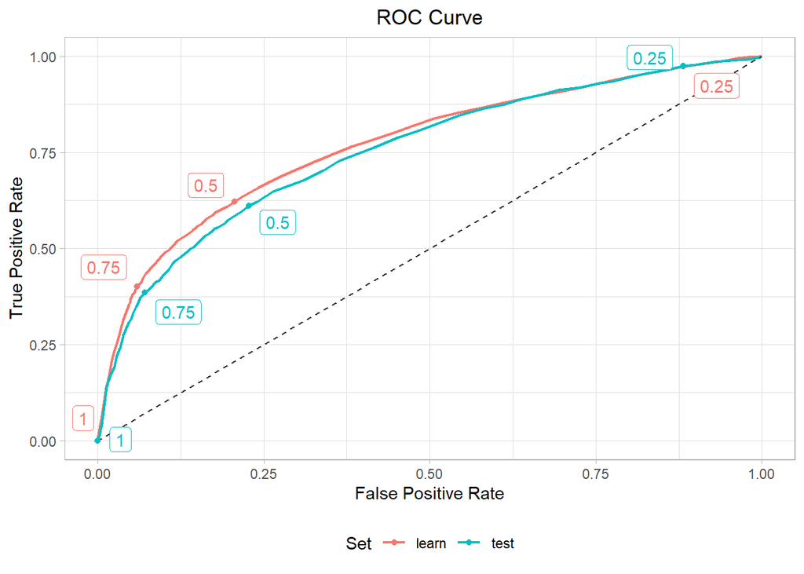

```r
plotROC(df_final$DEFAULT,df_final$y_pred, n_cutoff = 100, df_final$set)
```

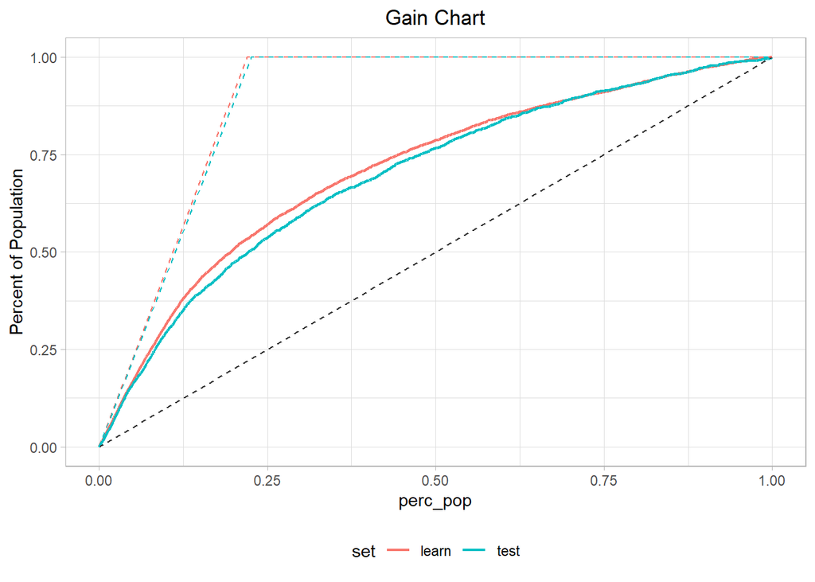

```r
plotGainChart(df_final, 'y_pred', 'DEFAULT', 'set')
```

```r
df_list <- scorecard(df_woebin, model)

for (i in seq_along(df_list)){
  df_list[[i]] <- list(df_list[[i]], names(df_list)[i])}
```

The result is quite satisfying. Model didn’t overfit, has good predictive power and is easy to explain, which is very important concerning nature of business problem (risk among credit cards clients). Model can help in recognizing potential defaulting clients, but there is a large group of Bad Clients (Default = 1), which haven’t been spotted (received low probability of default: peak around probability of 0.4), which is a space for further improvement. To summarise we will create scorecard for this model.

## Scorecard

```r
for (i in seq_along(df_list)){
  tmp <- df_list[[i]]
  cat('###', tmp[[2]], " \n")
  print(data.frame(tmp[[1]]) %>%kable() %>% kable_styling() %>% scroll_box(width = '750px'))
  cat('\n\n')}
```

### basepoints

| variable | bin | woe | points |
| --- | --- | --- | --- |
| basepoints | NA | NA | 379 |

### LIMIT_BAL

| variable | bin | count | count_distr | good | bad | badprob | woe | bin_iv | total_iv | breaks | is_special_values | points |
| --- | --- | --- | --- | --- | --- | --- | --- | --- | --- | --- | --- | --- |
| LIMIT_BAL | [-Inf,40000) | 3060 | 0.1360000 | 1949 | 1111 | 0.3630719 | 0.7064617 | 0.0805082 | 0.1821413 | 40000 | FALSE | -24 |
| LIMIT_BAL | [40000,140000) | 7810 | 0.3471111 | 5818 | 1992 | 0.2550576 | 0.1967003 | 0.0141660 | 0.1821413 | 140000 | FALSE | -7 |
| LIMIT_BAL | [140000,380000) | 9829 | 0.4368444 | 8193 | 1636 | 0.1664462 | -0.3425082 | 0.0463427 | 0.1821413 | 380000 | FALSE | 12 |
| LIMIT_BAL | [380000, Inf) | 1801 | 0.0800444 | 1601 | 200 | 0.1110494 | -0.8115487 | 0.0411243 | 0.1821413 | Inf | FALSE | 27 |

### PAY_0

| variable | bin | count | count_distr | good | bad | badprob | woe | bin_iv | total_iv | breaks | is_special_values | points |
| --- | --- | --- | --- | --- | --- | --- | --- | --- | --- | --- | --- | --- |
| PAY_0 | [-Inf,0) | 6392 | 0.2840889 | 5435 | 957 | 0.1497184 | -0.4682938 | 0.0541950 | 0.9097215 | 0 | FALSE | 27 |
| PAY_0 | [0,1) | 11041 | 0.4907111 | 9647 | 1394 | 0.1262567 | -0.6659520 | 0.1778751 | 0.9097215 | 1 | FALSE | 39 |
| PAY_0 | [1,2) | 2748 | 0.1221333 | 1789 | 959 | 0.3489811 | 0.6449966 | 0.0595302 | 0.9097215 | 2 | FALSE | -37 |
| PAY_0 | [2, Inf) | 2319 | 0.1030667 | 690 | 1629 | 0.7024580 | 2.1275477 | 0.6181212 | 0.9097215 | Inf | FALSE | -123 |

### PAY_4

| variable | bin | count | count_distr | good | bad | badprob | woe | bin_iv | total_iv | breaks | is_special_values | points |
| --- | --- | --- | --- | --- | --- | --- | --- | --- | --- | --- | --- | --- |
| PAY_4 | [-Inf,0) | 7571 | 0.3364889 | 6280 | 1291 | 0.1705191 | -0.3134352 | 0.0301593 | 0.3741321 | 0 | FALSE | 11 |
| PAY_4 | [0,1) | 12356 | 0.5491556 | 10111 | 2245 | 0.1816931 | -0.2364008 | 0.0286563 | 0.3741321 | 1 | FALSE | 9 |
| PAY_4 | [1, Inf) | 2573 | 0.1143556 | 1170 | 1403 | 0.5452779 | 1.4501267 | 0.3153166 | 0.3741321 | Inf | FALSE | -53 |

### PAY_AMT1

| variable | bin | count | count_distr | good | bad | badprob | woe | bin_iv | total_iv | breaks | is_special_values | points |
| --- | --- | --- | --- | --- | --- | --- | --- | --- | --- | --- | --- | --- |
| PAY_AMT1 | [-Inf,500) | 5037 | 0.2238667 | 3369 | 1668 | 0.3311495 | 0.5655270 | 0.0824960 | 0.1659526 | 500 | FALSE | -11 |
| PAY_AMT1 | [500,4500) | 10874 | 0.4832889 | 8529 | 2345 | 0.2156520 | -0.0226691 | 0.0002468 | 0.1659526 | 4500 | FALSE | 0 |
| PAY_AMT1 | [4500,17500) | 5391 | 0.2396000 | 4577 | 814 | 0.1509924 | -0.4583210 | 0.0439180 | 0.1659526 | 17500 | FALSE | 9 |
| PAY_AMT1 | [17500, Inf) | 1198 | 0.0532444 | 1086 | 112 | 0.0934891 | -1.0032400 | 0.0392918 | 0.1659526 | Inf | FALSE | 20 |

### PAY_AMT2

| variable | bin | count | count_distr | good | bad | badprob | woe | bin_iv | total_iv | breaks | is_special_values | points |
| --- | --- | --- | --- | --- | --- | --- | --- | --- | --- | --- | --- | --- |
| PAY_AMT2 | [-Inf,500) | 5115 | 0.2273333 | 3509 | 1606 | 0.3139785 | 0.4869332 | 0.0610367 | 0.1518592 | 500 | FALSE | -14 |
| PAY_AMT2 | [500,2000) | 5100 | 0.2266667 | 3920 | 1180 | 0.2313725 | 0.0679404 | 0.0010662 | 0.1518592 | 2000 | FALSE | -2 |
| PAY_AMT2 | [2000,5000) | 6300 | 0.2800000 | 4981 | 1319 | 0.2093651 | -0.0602391 | 0.0009989 | 0.1518592 | 5000 | FALSE | 2 |
| PAY_AMT2 | [5000,14500) | 4441 | 0.1973778 | 3737 | 704 | 0.1585229 | -0.4007424 | 0.0281570 | 0.1518592 | 14500 | FALSE | 11 |
| PAY_AMT2 | [14500, Inf) | 1544 | 0.0686222 | 1414 | 130 | 0.0841969 | -1.1181257 | 0.0606004 | 0.1518592 | Inf | FALSE | 31 |

### PAY_AMT5

| variable | bin | count | count_distr | good | bad | badprob | woe | bin_iv | total_iv | breaks | is_special_values | points |
| --- | --- | --- | --- | --- | --- | --- | --- | --- | --- | --- | --- | --- |
| PAY_AMT5 | [-Inf,500) | 6635 | 0.2948889 | 4801 | 1834 | 0.2764130 | 0.3061928 | 0.0299886 | 0.0871258 | 500 | FALSE | -5 |
| PAY_AMT5 | [500,2000) | 5553 | 0.2468000 | 4259 | 1294 | 0.2330272 | 0.0772215 | 0.0015035 | 0.0871258 | 2000 | FALSE | -1 |
| PAY_AMT5 | [2000,4000) | 4311 | 0.1916000 | 3425 | 886 | 0.2055208 | -0.0836221 | 0.0013083 | 0.0871258 | 4000 | FALSE | 1 |
| PAY_AMT5 | [4000,14500) | 4700 | 0.2088889 | 3913 | 787 | 0.1674468 | -0.3353137 | 0.0212855 | 0.0871258 | 14500 | FALSE | 5 |
| PAY_AMT5 | [14500, Inf) | 1301 | 0.0578222 | 1163 | 138 | 0.1060723 | -0.8629868 | 0.0330398 | 0.0871258 | Inf | FALSE | 13 |

### PAY_AMT6

| variable | bin | count | count_distr | good | bad | badprob | woe | bin_iv | total_iv | breaks | is_special_values | points |
| --- | --- | --- | --- | --- | --- | --- | --- | --- | --- | --- | --- | --- |
| PAY_AMT6 | [-Inf,1000) | 8780 | 0.3902222 | 6399 | 2381 | 0.2711845 | 0.2798965 | 0.0329422 | 0.0928499 | 1000 | FALSE | -4 |
| PAY_AMT6 | [1000,3000) | 6002 | 0.2667556 | 4657 | 1345 | 0.2240920 | 0.0265402 | 0.0001893 | 0.0928499 | 3000 | FALSE | 0 |
| PAY_AMT6 | [3000,10000) | 5518 | 0.2452444 | 4577 | 941 | 0.1705328 | -0.3133382 | 0.0219681 | 0.0928499 | 10000 | FALSE | 4 |
| PAY_AMT6 | [10000, Inf) | 2200 | 0.0977778 | 1928 | 272 | 0.1236364 | -0.6899188 | 0.0377502 | 0.0928499 | Inf | FALSE | 9 |

### SEX

| variable | bin | count | count_distr | good | bad | badprob | woe | bin_iv | total_iv | breaks | is_special_values | points |
| --- | --- | --- | --- | --- | --- | --- | --- | --- | --- | --- | --- | --- |
| SEX | female | 13640 | 0.6062222 | 10824 | 2816 | 0.2064516 | -0.0779308 | 0.0036012 | 0.0088568 | female | FALSE | 4 |
| SEX | male | 8860 | 0.3937778 | 6737 | 2123 | 0.2396163 | 0.1137331 | 0.0052556 | 0.0088568 | male | FALSE | -6 |

### MARRIAGE

| variable | bin | count | count_distr | good | bad | badprob | woe | bin_iv | total_iv | breaks | is_special_values | points |
| --- | --- | --- | --- | --- | --- | --- | --- | --- | --- | --- | --- | --- |
| MARRIAGE | married%,%others | 10530 | 0.468 | 8088 | 2442 | 0.2319088 | 0.0709535 | 0.0024029 | 0.0045987 | married%,%others | FALSE | -6 |
| MARRIAGE | single%,%missing | 11970 | 0.532 | 9473 | 2497 | 0.2086048 | -0.0648380 | 0.0021958 | 0.0045987 | single%,%missing | FALSE | 6 |

# BONUS: Random Forest approach

To establish reference point for our logistic regression model, we will quickly build random forest model (using very fast ranger package) for the same data (before WoE transformation) with some arbitrarily chosen hyperparameters, with no hyperparameter tuning.

```r
library(ranger)

ranger_model <- ranger(DEFAULT ~.,
                       data = df_learn,
                       probability = TRUE,
                       max.depth = 7,
                       min.node.size = 20,
                       mtry= 5,
                       case.weights = weights_vec)

df_ranger_learn <- df_learn
df_ranger_learn$y_pred <- ranger_model$predictions[,2]
df_ranger_learn$set <- 'learn'


df_ranger_test <- df_test
df_ranger_test$y_pred <- predict(ranger_model, data = df_test, type = "response")$prediction[,2]
df_ranger_test$set <- 'test'

df_ranger_final <- rbind(df_ranger_learn, df_ranger_test)

df_ranger_final$y_pred_bin <- cut(df_ranger_final$y_pred,
                                  breaks = quantile(df_ranger_final$y_pred,
                                                    probs = seq(0, 1, by = 0.1)),
                                  include.lowest = TRUE,
                                  right = TRUE)
```

## Diagnostics

```r
df_ranger_final %>%
  group_by(set) %>%
  summarise(
    Gini = MLmetrics::Gini(y_pred, DEFAULT),
    AUC = MLmetrics::AUC(y_pred, DEFAULT)
  ) %>%
  kable() %>% kable_styling(full_width = F)
```

| set | Gini | AUC |
| --- | --- | --- |
| learn | 0.5612743 | 0.7806372 |
| test | 0.5369485 | 0.7684742 |

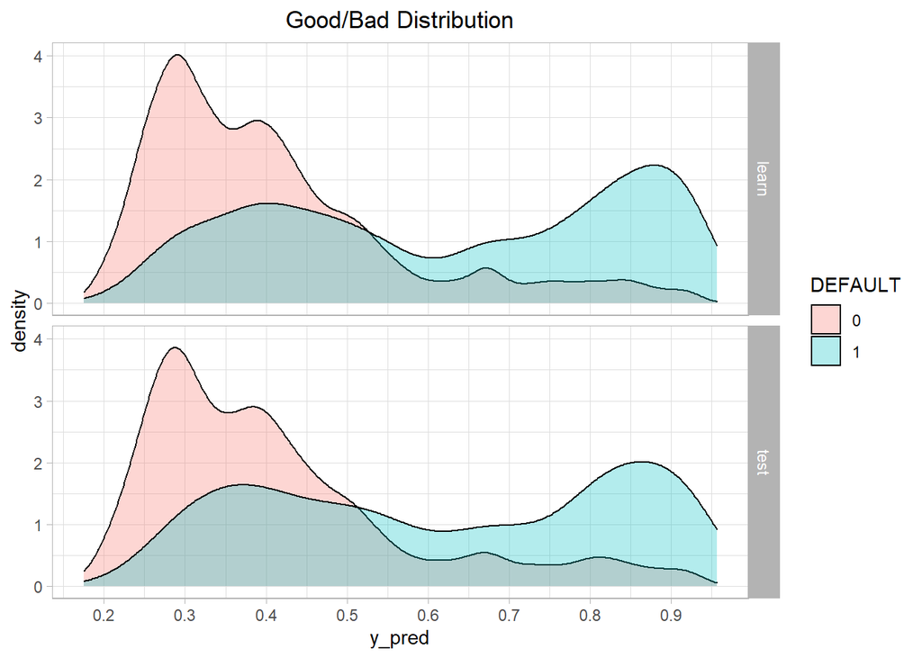

```r
plotGoodBadDist(df_ranger_final,'y_pred', 'DEFAULT', 'set' )
```

[figure not shown]

```r
plotSuccessRateInBins(df_ranger_final,'y_pred_bin','DEFAULT', 'set', 'Default Rate' )
```

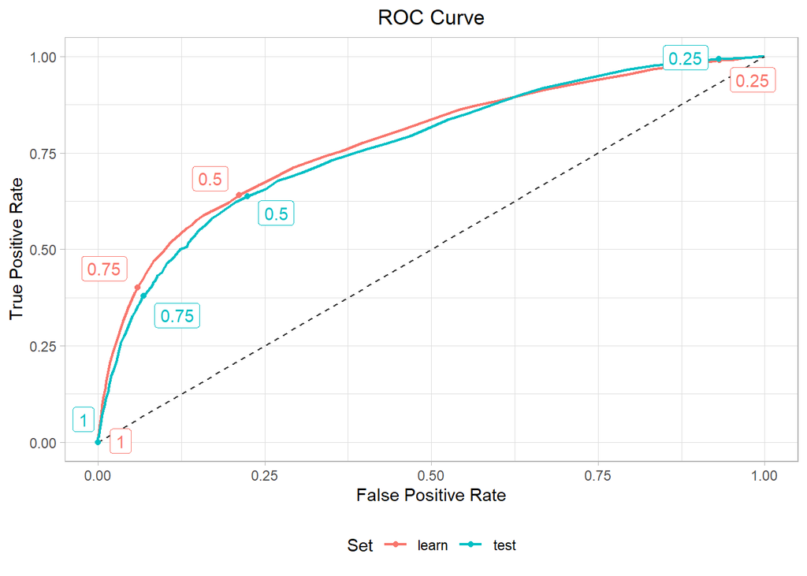

```r
plotROC(df_ranger_final$DEFAULT,df_ranger_final$y_pred, n_cutoff = 100, df_ranger_final$set)
```

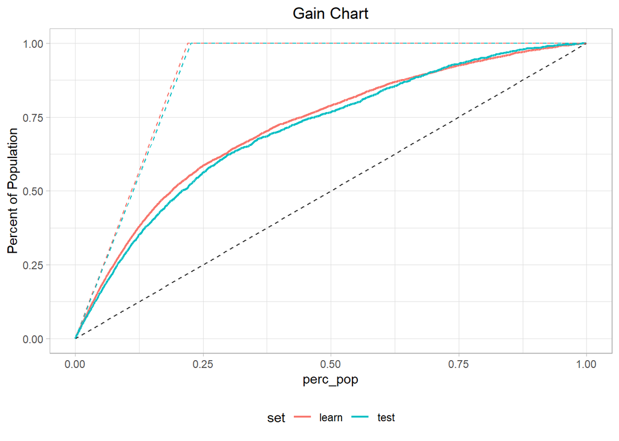

```r
plotGainChart(df_ranger_final, 'y_pred', 'DEFAULT', 'set')
```